# Big Data Programming Exercise 3

```python
import pandas as pd
import configparser
from sklearn.linear_model import LinearRegression
import numpy as np
import matplotlib.pyplot as plt
import statsmodels.api as sm
from sklearn.decomposition import PCA
from sklearn.model_selection import train_test_split
from sklearn.linear_model import LogisticRegression
default_seed = 1
```

Because the housing data was ‘.csv’ format, the code to read the csv was used to obtain the database.

```python
HouseData = pd.read_csv('/Users/yangruiling/Desktop/iftbigdatacoursework2019/RuilingYang/csv/train.csv')
```

Then for checking and learning the whole data, I used the head function.

```python
HouseData.head()
```

|  | id | timestamp | full_sq | life_sq | floor | max_floor | material | build_year | num_room | kitch_sq | ... | cafe_count_5000_price_2500 | cafe_count_5000_price_4000 | cafe_count_5000_price_high | big_church_count_5000 | church_count_5000 | mosque_count_5000 | leisure_count_5000 | sport_count_5000 | market_count_5000 | price_doc |
| --- | --- | --- | --- | --- | --- | --- | --- | --- | --- | --- | --- | --- | --- | --- | --- | --- | --- | --- | --- | --- | --- |
| 0 | 1 | 2011-08-20 | 43 | 27.0 | 4.0 | NaN | NaN | NaN | NaN | NaN | ... | 9 | 4 | 0 | 13 | 22 | 1 | 0 | 52 | 4 | 5850000 |
| 1 | 2 | 2011-08-23 | 34 | 19.0 | 3.0 | NaN | NaN | NaN | NaN | NaN | ... | 15 | 3 | 0 | 15 | 29 | 1 | 10 | 66 | 14 | 6000000 |
| 2 | 3 | 2011-08-27 | 43 | 29.0 | 2.0 | NaN | NaN | NaN | NaN | NaN | ... | 10 | 3 | 0 | 11 | 27 | 0 | 4 | 67 | 10 | 5700000 |
| 3 | 4 | 2011-09-01 | 89 | 50.0 | 9.0 | NaN | NaN | NaN | NaN | NaN | ... | 11 | 2 | 1 | 4 | 4 | 0 | 0 | 26 | 3 | 13100000 |
| 4 | 5 | 2011-09-05 | 77 | 77.0 | 4.0 | NaN | NaN | NaN | NaN | NaN | ... | 319 | 108 | 17 | 135 | 236 | 2 | 91 | 195 | 14 | 16331452 |

5 rows × 292 columns

After finding that there are too many columns and I cannot know all about the feature label, the ‘iloc’ code was used to view every labels for each columns. Through using the ‘info’ code, we also can be clear about the data type for each columns.

```python
HouseData.iloc[:,15:30]
```

|  | green_zone_part | indust_part | children_preschool | preschool_quota | preschool_education_centers_raion | children_school | school_quota | school_education_centers_raion | school_education_centers_top_20_raion | hospital_beds_raion | healthcare_centers_raion | university_top_20_raion | sport_objects_raion | additional_education_raion | culture_objects_top_25 |
| --- | --- | --- | --- | --- | --- | --- | --- | --- | --- | --- | --- | --- | --- | --- | --- |
| 0 | 0.189727 | 0.000070 | 9576 | 5001.0 | 5 | 10309 | 11065.0 | 5 | 0 | 240.0 | 1 | 0 | 7 | 3 | no |
| 1 | 0.372602 | 0.049637 | 6880 | 3119.0 | 5 | 7759 | 6237.0 | 8 | 0 | 229.0 | 1 | 0 | 6 | 1 | yes |
| 2 | 0.112560 | 0.118537 | 5879 | 1463.0 | 4 | 6207 | 5580.0 | 7 | 0 | 1183.0 | 1 | 0 | 5 | 1 | no |
| 3 | 0.194703 | 0.069753 | 13087 | 6839.0 | 9 | 13670 | 17063.0 | 10 | 0 | NaN | 1 | 0 | 17 | 6 | no |
| 4 | 0.015234 | 0.037316 | 5706 | 3240.0 | 7 | 6748 | 7770.0 | 9 | 0 | 562.0 | 4 | 2 | 25 | 2 | no |
| ... | ... | ... | ... | ... | ... | ... | ... | ... | ... | ... | ... | ... | ... | ... | ... |
| 30466 | 0.096270 | 0.300323 | 9753 | 5088.0 | 4 | 10311 | 12721.0 | 4 | 0 | NaN | 1 | 0 | 10 | 3 | no |
| 30467 | 0.065444 | 0.000078 | 4237 | 1874.0 | 4 | 6398 | 6772.0 | 4 | 1 | 1046.0 | 3 | 2 | 29 | 16 | yes |
| 30468 | 0.496315 | 0.007122 | 275 | NaN | 0 | 264 | NaN | 0 | 0 | NaN | 0 | 0 | 0 | 0 | no |
| 30469 | 0.167526 | 0.093443 | 4215 | 2372.0 | 6 | 4635 | 6083.0 | 8 | 0 | 3300.0 | 2 | 1 | 11 | 1 | no |
| 30470 | 0.063755 | 0.038693 | 6120 | 2215.0 | 4 | 6533 | 5824.0 | 4 | 0 | 1015.0 | 2 | 0 | 7 | 1 | no |

30471 rows × 15 columns

```python
len(HouseData)
```

```
30471
```

Through using the ‘info’ code, we also can be clear about the data type for each columns.

```python
HouseData.info()
```

```
<class 'pandas.core.frame.DataFrame'>
RangeIndex: 30471 entries, 0 to 30470
Columns: 292 entries, id to price_doc
dtypes: float64(119), int64(157), object(16)
memory usage: 67.9+ MB
```

In order to analysis what features of house can affect the price of the house, the correlation matrix of price and other features was obtained by coding, and sorted the results in descending.

```python
corr_matrix = HouseData.corr()
corr_matrix["price_doc"].sort_values(ascending=False)
```

```
price_doc             1.000000
num_room              0.476337
full_sq               0.341840
sport_count_5000      0.294864
sport_count_3000      0.290651
                        ...
ttk_km               -0.272620
bulvar_ring_km       -0.279158
kremlin_km           -0.279249
sadovoe_km           -0.283622
zd_vokzaly_avto_km   -0.284069
Name: price_doc, Length: 276, dtype: float64
```

After processing the correlation matrix, we can find that number of rooms and full square are the most positively correlated to price. Therefore, I plot the scatter figure separately for these two features

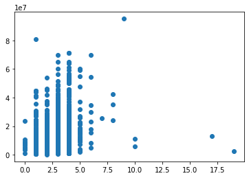

```python
plt.scatter(HouseData.num_room,HouseData.price_doc)
```

According to this results, for number of rooms and price, the relationship was more like classification than linear regression.

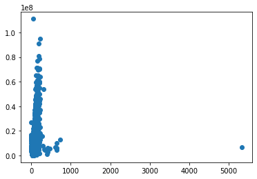

```python
plt.scatter(HouseData.full_sq,HouseData.price_doc)
```

For full square and price, the extreme outliers make the relationship very fuzzy.

Then I want to calculate the covariance of number of rooms and price as well as the covariance of full square and price.

```python
HouseData[['price_doc','num_room' ]].cov()
```

|  | price_doc | num_room |
| --- | --- | --- |
| price_doc | 2.284946e+13 | 1.989521e+06 |
| num_room | 1.989521e+06 | 7.255709e-01 |

```python
HouseData[['price_doc', 'full_sq']].cov()
```

|  | price_doc | full_sq |
| --- | --- | --- |
| price_doc | 2.284946e+13 | 6.214480e+07 |
| full_sq | 6.214480e+07 | 1.446394e+03 |

To measure the relationship deeply, I set the full square and number of rooms as the independent variables: x1 and x2 separately, and I set the price as the dependent variable.

```python
x1= 'full_sq'
x2= 'num_room'
y= 'price_doc'
```

I create two Linear Regression Model to test the possibility that how the independent variable explain the dependent variable.

```python
parameters = HouseData[[x1, y]]
Linearmodel1 = LinearRegression()
Linearmodel1.fit(parameters[x1].values.reshape(-1, 1), parameters[y])
```

```
LinearRegression(copy_X=True, fit_intercept=True, n_jobs=None, normalize=False)
```

```python
alpha1 =Linearmodel1.intercept_
beta1 =Linearmodel1.coef_
```

```python
alpha1
```

```
4793701.233165987
```

```python
beta1
```

```
array([42965.33134955])
```

Because of difference of value range, the alpha and beta were big.

```python
Linearmodel1.score(parameters[x1].values.reshape(-1, 1), parameters[y])
```

```
0.116854899924701
```

This score shows that full square cannot explain the price well. Considering about the range between full square and price, I took log for the price and create a new model to estimate.

```python
Linearmodel1_1 = LinearRegression()
Linearmodel1_1.fit(parameters[x1].values.reshape(-1, 1), np.log(parameters[y]))
```

```
LinearRegression(copy_X=True, fit_intercept=True, n_jobs=None, normalize=False)
```

```python
alpha1_1=Linearmodel1_1.intercept_
beta1_1=Linearmodel1_1.coef_
```

```python
alpha1_1
```

```
15.375576628328677
```

```python
beta1_1
```

```
array([0.00431448])
```

```python
Linearmodel1_1.score(parameters[x1].values.reshape(-1, 1), np.log(parameters[y]))
```

```
0.07366201547889784
```

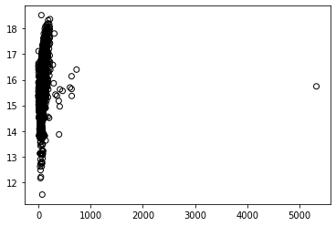

```python
plt.scatter(HouseData[x1], np.log(HouseData[y]), marker='o', color='', edgecolors='k')
```

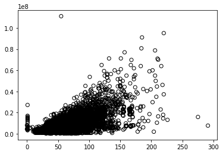

```python
HouseData = HouseData[(HouseData[x1] < 300)]
plt.scatter(HouseData[x1], HouseData[y], marker='o', color='', edgecolors='k')
```

Then I creat a new model without outliers to make the regression.

```python
HouseDataDrop=HouseData[(HouseData[x1] < 300)]
```

```python
parameters1_2 = HouseDataDrop[[x1, y]]
Linearmodel1_2 = LinearRegression()
Linearmodel1_2.fit(parameters1_2[x1].values.reshape(-1, 1), parameters1_2[y])
alpha1_2=Linearmodel1_2.intercept_
beta1_2=Linearmodel1_2.coef_
```

```python
print('alpha1_2 = ',alpha1_2, '\n', 'beta1_2 = ',beta1_2)
```

```
alpha1_2 =  -326782.6790794227
 beta1_2 =  [138303.48191261]
```

```python
Linearmodel1_2.score(parameters1_2[x1].values.reshape(-1, 1), parameters1_2[y])
```

```
0.3759626055873815
```

This score is higher than before, thus the outliers indeed affect the results of regression.

```python
MeanSSR = np.mean(parameters1_2[y]-model.predict(parameters[x1].values.reshape(-1, 1)))
MeanSSR
```

```
7121968.324253274
```

Then we start another estimation of the linear regression model from number of rooms and price.

```python
parameters = HouseData[[x2, y]].dropna()
Linearmodel2 = LinearRegression()
Linearmodel2.fit(parameters[x2].values.reshape(-1, 1), parameters[y])
```

```
LinearRegression(copy_X=True, fit_intercept=True, n_jobs=None, normalize=False)
```

```python
alpha3 =Linearmodel2.intercept_
beta3 =Linearmodel2.coef_
```

```python
alpha3
```

```
2230442.78122754
```

```python
beta3
```

```
array([2742007.8260498])
```

```python
Linearmodel2.score(parameters[x2].values.reshape(-1, 1), parameters[y])
```

```
0.22689649743949025
```

In this model, the beta and alpha is still very high because of the range gap. And the score of this mode is 0.2268964974, which is also not good and means it cannot explain the dependent variable.

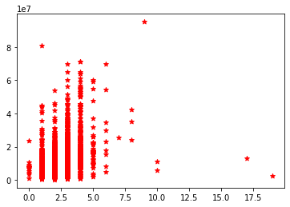

```python
plt.scatter(parameters[x2], parameters[y],marker='*', color='r')
```

Through the results above, we can see that one dimensional regression is not enough to explain the price. Therefore, according to the correlation results above and the life experience, I select twelve feature variables as the independent variables to build the multiple linear regression model with price.

Because of NA variable, I use ‘loc’ and ‘dropna’ code to process the data to a new database.

```python
HousePrice= HouseData.loc[:,('num_room','full_sq','area_m','green_zone_part','healthcare_centers_raion','indust_part','children_preschool','shopping_centers_raion','sport_count_5000','sadovoe_km','kremlin_km','zd_vokzaly_avto_km','price_doc')].dropna(how='any')
```

```python
HousePrice
```

|  | num_room | full_sq | area_m | green_zone_part | healthcare_centers_raion | indust_part | children_preschool | shopping_centers_raion | sport_count_5000 | sadovoe_km | kremlin_km | zd_vokzaly_avto_km | price_doc |
| --- | --- | --- | --- | --- | --- | --- | --- | --- | --- | --- | --- | --- | --- |
| 7672 | 2.0 | 73 | 1.488362e+07 | 0.024444 | 1 | 0.158249 | 7567 | 0 | 17 | 14.824881 | 16.934712 | 22.217934 | 10100000 |
| 8056 | 1.0 | 11 | 1.007156e+07 | 0.048791 | 5 | 0.000000 | 6374 | 5 | 161 | 0.189294 | 2.109561 | 4.742795 | 2750000 |
| 8111 | 3.0 | 85 | 2.553630e+07 | 0.496315 | 0 | 0.007122 | 275 | 1 | 9 | 20.412259 | 22.450272 | 26.263040 | 7574496 |
| 8135 | 2.0 | 53 | 5.646405e+06 | 0.258663 | 3 | 0.101872 | 4857 | 3 | 46 | 13.270117 | 15.345902 | 13.396969 | 9000000 |
| 8144 | 1.0 | 41 | 2.149409e+07 | 0.262459 | 0 | 0.017647 | 489 | 0 | 12 | 23.724567 | 25.701769 | 28.972859 | 4457400 |
| ... | ... | ... | ... | ... | ... | ... | ... | ... | ... | ... | ... | ... | ... |
| 30466 | 2.0 | 44 | 1.005305e+07 | 0.096270 | 1 | 0.300323 | 9753 | 9 | 84 | 10.543724 | 12.599292 | 11.396447 | 7400000 |
| 30467 | 4.0 | 86 | 7.307411e+06 | 0.065444 | 3 | 0.000078 | 4237 | 23 | 171 | 1.203215 | 3.269284 | 1.010437 | 25000000 |
| 30468 | 1.0 | 45 | 2.553630e+07 | 0.496315 | 0 | 0.007122 | 275 | 1 | 11 | 19.868997 | 21.905792 | 25.699461 | 6970959 |
| 30469 | 2.0 | 64 | 6.050065e+06 | 0.167526 | 2 | 0.093443 | 4215 | 4 | 65 | 11.752036 | 13.622569 | 15.303338 | 13500000 |
| 30470 | 2.0 | 43 | 4.395333e+06 | 0.063755 | 2 | 0.038693 | 6120 | 5 | 54 | 9.675169 | 11.812614 | 12.243439 | 5600000 |

20899 rows × 13 columns

```python
x=HousePrice[['num_room','full_sq','area_m','green_zone_part','healthcare_centers_raion','indust_part','children_preschool','shopping_centers_raion','sport_count_5000','sadovoe_km','kremlin_km','zd_vokzaly_avto_km']]
y=HousePrice['price_doc']
```

```python
MultiRegress=LinearRegression()
MultiRegress.fit(x,y)
```

```
LinearRegression(copy_X=True, fit_intercept=True, n_jobs=None, normalize=False)
```

```python
Mulalpha=MultiRegress.intercept_
Mulbeta=MultiRegress.coef_
```

```python
Mulalpha
```

```
-2634445.2029381804
```

```python
Mulbeta
```

```
array([ 1.44918002e+05,  1.30722753e+05, -1.12832724e-02, -1.45911489e+06,
       -3.44747895e+04, -5.26748234e+06,  3.66210862e+01, -3.71421947e+03,
        2.71520872e+04, -1.62964593e+06,  1.59224623e+06, -1.95498943e+04])
```

```python
MultiRegress.score(x,y)
```

```
0.5038174233309587
```

In this model, the score is 0.503817423, which is much higher than before. However, this result is still not very good. Therefore, through summary the problem above and possible problems, I decide to classify the price into two levels by comparing with the mean of price, and this processing can eliminate the problem of outliers. By classifying the price into two groups, we only consider about how the inputs makes the price of house high or low.

```python
HouseData.price_doc.describe()
```

[output not shown]

```python
HouseData['PriceClass']=HouseData.price_doc> np.mean(HouseData.price_doc)
```

```python
HouseData['PriceClass']
```

[output not shown]

```python
HouseData
```

|  | id | timestamp | full_sq | life_sq | floor | max_floor | material | build_year | num_room | kitch_sq | ... | cafe_count_5000_price_4000 | cafe_count_5000_price_high | big_church_count_5000 | church_count_5000 | mosque_count_5000 | leisure_count_5000 | sport_count_5000 | market_count_5000 | price_doc | PriceClass |
| --- | --- | --- | --- | --- | --- | --- | --- | --- | --- | --- | --- | --- | --- | --- | --- | --- | --- | --- | --- | --- | --- |
| 0 | 1 | 2011-08-20 | 43 | 27.0 | 4.0 | NaN | NaN | NaN | NaN | NaN | ... | 4 | 0 | 13 | 22 | 1 | 0 | 52 | 4 | 5850000 | False |
| 1 | 2 | 2011-08-23 | 34 | 19.0 | 3.0 | NaN | NaN | NaN | NaN | NaN | ... | 3 | 0 | 15 | 29 | 1 | 10 | 66 | 14 | 6000000 | False |
| 2 | 3 | 2011-08-27 | 43 | 29.0 | 2.0 | NaN | NaN | NaN | NaN | NaN | ... | 3 | 0 | 11 | 27 | 0 | 4 | 67 | 10 | 5700000 | False |
| 3 | 4 | 2011-09-01 | 89 | 50.0 | 9.0 | NaN | NaN | NaN | NaN | NaN | ... | 2 | 1 | 4 | 4 | 0 | 0 | 26 | 3 | 13100000 | True |
| 4 | 5 | 2011-09-05 | 77 | 77.0 | 4.0 | NaN | NaN | NaN | NaN | NaN | ... | 108 | 17 | 135 | 236 | 2 | 91 | 195 | 14 | 16331452 | True |
| ... | ... | ... | ... | ... | ... | ... | ... | ... | ... | ... | ... | ... | ... | ... | ... | ... | ... | ... | ... | ... | ... |
| 30466 | 30469 | 2015-06-30 | 44 | 27.0 | 7.0 | 9.0 | 1.0 | 1975.0 | 2.0 | 6.0 | ... | 5 | 0 | 15 | 26 | 1 | 2 | 84 | 6 | 7400000 | True |
| 30467 | 30470 | 2015-06-30 | 86 | 59.0 | 3.0 | 9.0 | 2.0 | 1935.0 | 4.0 | 10.0 | ... | 128 | 24 | 98 | 182 | 1 | 82 | 171 | 15 | 25000000 | True |
| 30468 | 30471 | 2015-06-30 | 45 | NaN | 10.0 | 20.0 | 1.0 | NaN | 1.0 | 1.0 | ... | 1 | 0 | 2 | 12 | 0 | 1 | 11 | 1 | 6970959 | False |
| 30469 | 30472 | 2015-06-30 | 64 | 32.0 | 5.0 | 15.0 | 1.0 | 2003.0 | 2.0 | 11.0 | ... | 1 | 1 | 6 | 31 | 1 | 4 | 65 | 7 | 13500000 | True |
| 30470 | 30473 | 2015-06-30 | 43 | 28.0 | 1.0 | 9.0 | 1.0 | 1968.0 | 2.0 | 6.0 | ... | 2 | 0 | 7 | 16 | 0 | 9 | 54 | 10 | 5600000 | False |

```python
HousePrice1= HouseData.loc[:,('num_room','full_sq','area_m','green_zone_part','healthcare_centers_raion','indust_part','children_preschool','shopping_centers_raion','sport_count_5000','sadovoe_km','kremlin_km','zd_vokzaly_avto_km','PriceClass')].dropna(how='any')
```

```python
x=HousePrice1[['num_room','full_sq','area_m','green_zone_part','healthcare_centers_raion','indust_part','children_preschool','shopping_centers_raion','sport_count_5000','sadovoe_km','kremlin_km','zd_vokzaly_avto_km']]
y=HousePrice1['PriceClass']
```

Moreover, considering about the possibility of similar part among the independent variable, I use the principal component analysis (PCA) to remove the correlation among the independent variables.

```python
noise_var = []
exp_ratio = []
score=[]
for i in range(1, 13):
    PCAmodel = PCA(n_components=i)
    PCAmodel.fit(x, y)
    noise_var.append(PCAmodel.noise_variance_)
    score.append(PCAmodel.score(x,y))
```

After completing the for loop, I drawn the graphics of estimated noisy variance and the score for PCA model to find the best number of components

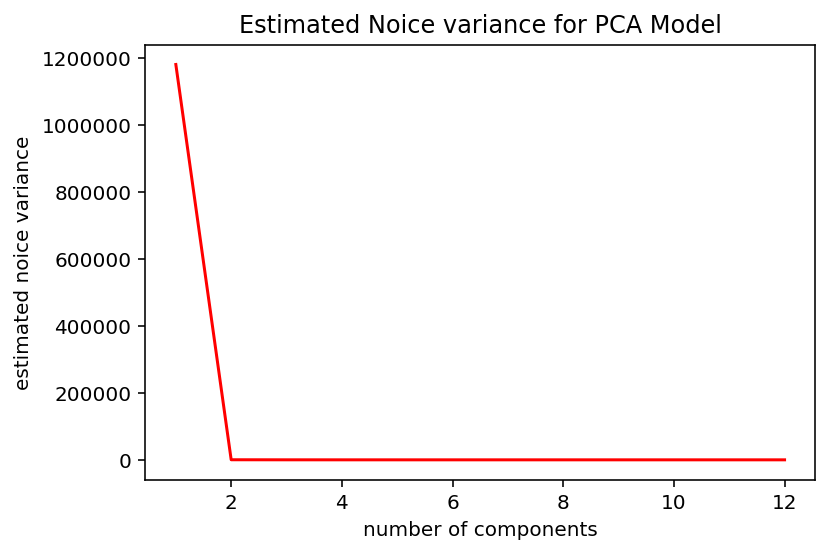

```python
%config InlineBackend.figure_format = 'retina'
fig, ax = plt.subplots()
_ = ax.set_title ("Estimated Noice variance for PCA Model")
_ = ax.plot(range(1, 13), noise_var,color='r')
_ = ax.set_ylabel("estimated noice variance")
_ = ax.set_xlabel('number of components')
```

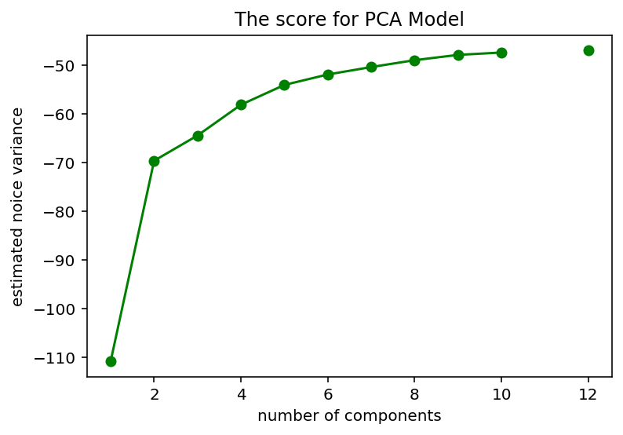

```python
%config InlineBackend.figure_format = 'retina'
fig, ax = plt.subplots()
_ = ax.set_title ("The score for PCA Model")
_ = ax.plot(range(1, 13), score,color='g',marker='o')
_ = ax.set_ylabel("estimated noice variance")
_ = ax.set_xlabel('number of components')
```

```python
PCRModel = PCA(n_components= 2)
PCRModel.fit(x, y)
x=PCRModel.transform(x)
```

```python
LogicRegress=LogisticRegression()
LogicRegress.fit(x,y)
LogicRegress.score(x,y)
```

```
0.57533853294416
```

In the conclusion, although the result is improved, this score is still not very good. We might need to try other regression approaches or other independent variables to explain the price.